# Presentation_12_1_2021 slides

**R****eally** **I****mportant:**

**Investigating** **Rapid Intensification** **in Tropical Atlantic Stroms**

**Samuel LeBlanc**  
**12/1/2021**

**What is** **Rapid Intensification (RI)****?**

**In meteorology, rapid intensification occurs when a tropical cyclone intensifies dramatically in a short period of time.**

**The National Hurricane Center defines rapid intensification as an increase in the maximum sustained winds of at least 30 knots (or 35 mph) in a 24-hour period.**

**Why should we care?**

**Hurricanes are notoriously difficult to predict, advanced meteorological models consistently have trouble predicting them, even 24 hours in advance. Even with an accurate predicition (which are uncommon), the logisitics of mass evacuations create a public policy nightmare for any city in the path of a hurricane.**

**The situation is even worse if the hurricane undergoes a **Rapid Intensification** event. Hurricanes have been known to approach landfall as a Category 1 storm, lulling people into a false sense of security, only to rapidly intensify into a Category 4 storm and cause massive devastation.**

**Question:**

**Can we use data science and machine learning methods to predict whether a hurricane will**  
**Rapidly Intensify****?**

**What do scientists know about** **RI** **hurricanes?**

- **High potential for mass devastation**
- **Hard to predict**
- **Correlated with 3 meteorological factors**
  - **Warm, deep water**
  - **Low wind shear**
  - **High humidity**

**Considered Approach:** **Rapid Deepening**

**The NHC previously defined **Rapid Deepening** as when the minimum central pressure of a storm decreased by 42 millibars (1.240 inHg) over a 24-hour period. In the last decade, the NHC moved away from the 'pressue-based' RI defintion to the current 'wind-based' definition.**

**However, research suggests that mean sea level pressure may be a better predictor than wind speed for hurricanes making landfall in the continental United States.**

**HURDAT2 Data**

**The NHC has compiled the best tracks of all Atlantic storms for at least the last century (~1900 storms in total) into one .txt file. Each row is an observation for one storm, taken every 6 hours, usually...**

**Example for Hurricane Irene:**

```
AL092011,  IRENE,  39,
20110821, 0000, TS, 15.0N,  59.0W,  45, 1006,  105, 0, 0,45, ... ,
20110821, 0600, TS, 16.0N,  60.6W,  45, 1006,  130, 0, 0,80, ... ,
20110821, 1200, TS, 16.8N,  62.2W,  45, 1005,  130, 0, 0,70, ... ,
20110821, 1800, TS, 17.5N,  63.7W,  50,  999,  130,20, 0,70, ... ,
20110822, 0000, TS, 17.9N,  65.0W,  60,  993,  130,30,30,90, ... ,
20110822, 0600, HU, 18.2N,  65.9W,  65,  990,  130,60,60,90, ... ,
20110822, 1200, HU, 18.9N,  67.0W,  70,  989,  160,60,60,90, ... ,
20110822, 1800, HU, 19.3N,  68.0W,  75,  988,  160,60,40,90, ... ,
```

**Transformed Data: Predictor Variables**

- Latitude
- Longitude
- Wind Speed
- Wind Acceleration
- Air Pressure
- 34kt Radius
- 50kt Radius
- 64kt Radius
- Eye Bearing
- Eye Speed
- Sea Surface Temperature(SST)
- Wind Shear
- Water Vapor

**Data Source for SST, Wind Shear, and Water Vapor 😖**

[figure not shown]

**Tools**

**Data Wrangling**

- **pandas**
- **Image (module)**

**Data Visualizations**

- **matplotlib**
- **ggplot,ggmap (in R)**

**Machine Learning**

- **sklearn**

**Findings:**

**Both the total number of hurricanes and the proportion of them that are** **Rapidly Intensifying** **have increased.**

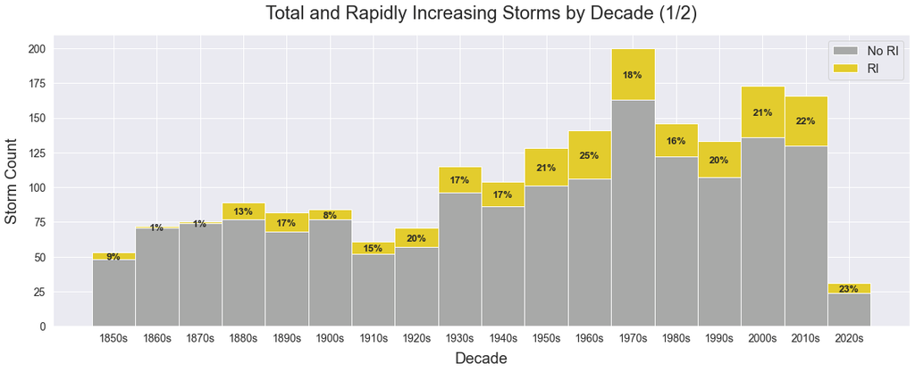

**Findings:**

**The proportion of hurricanes that are** **Rapidly Intensifying** **has increased faster than the total number of hurricanes.**

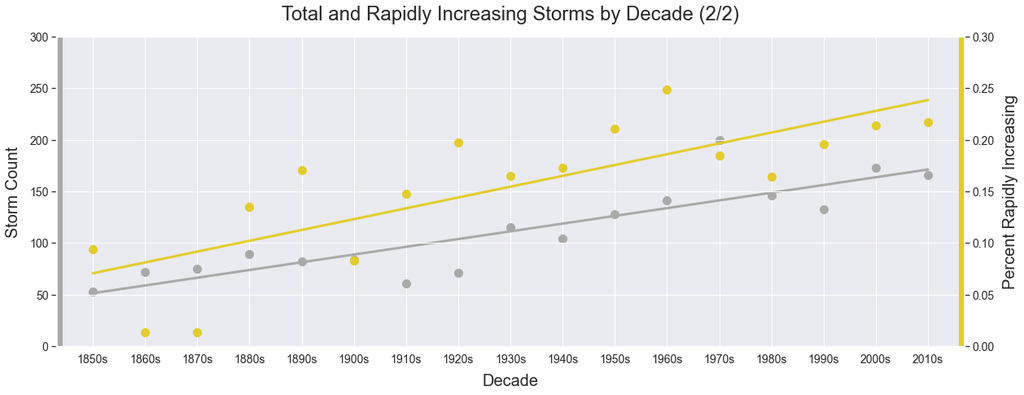

**Findings:**

**The proportion of hurricanes reaching 'major' status (Category 3, 4, 5) has increased**

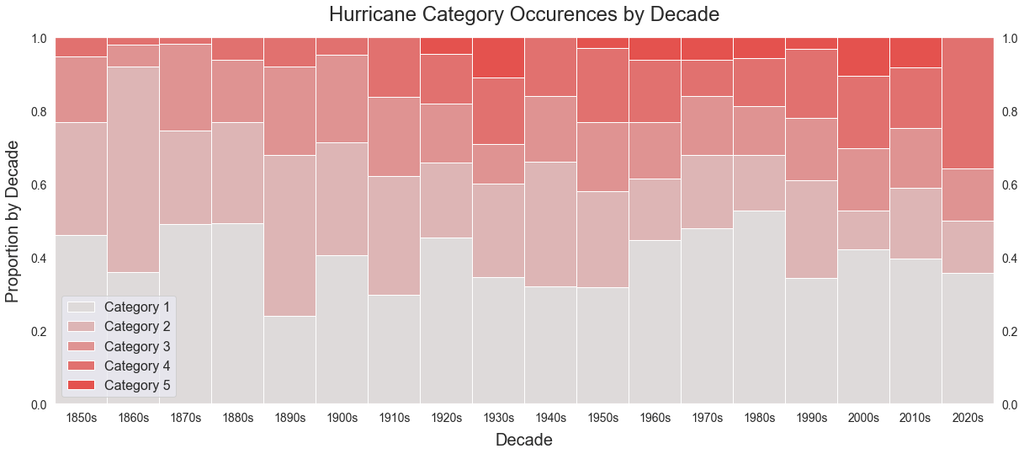

**More Data Viz**

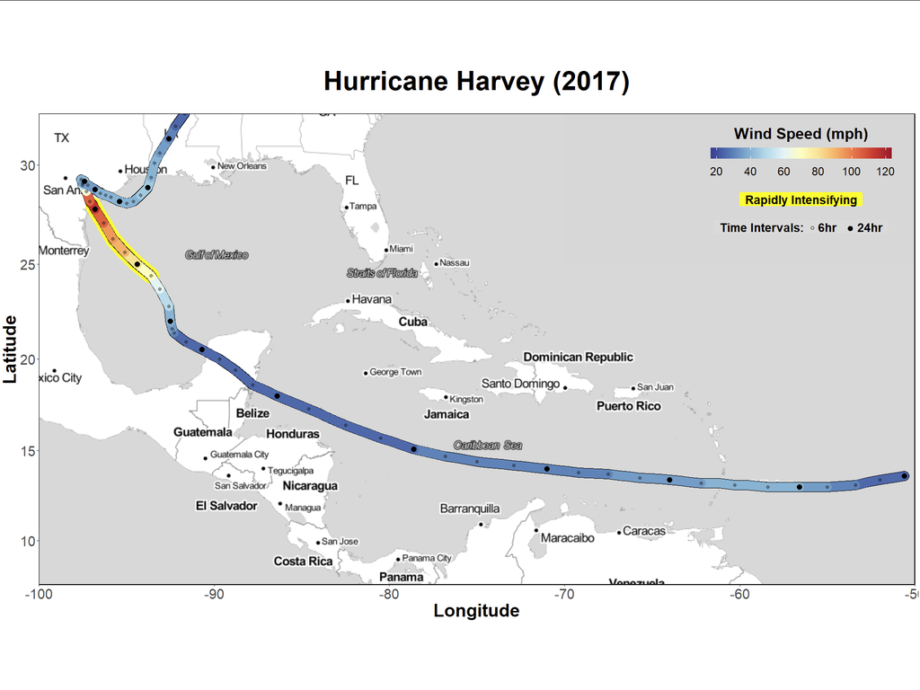

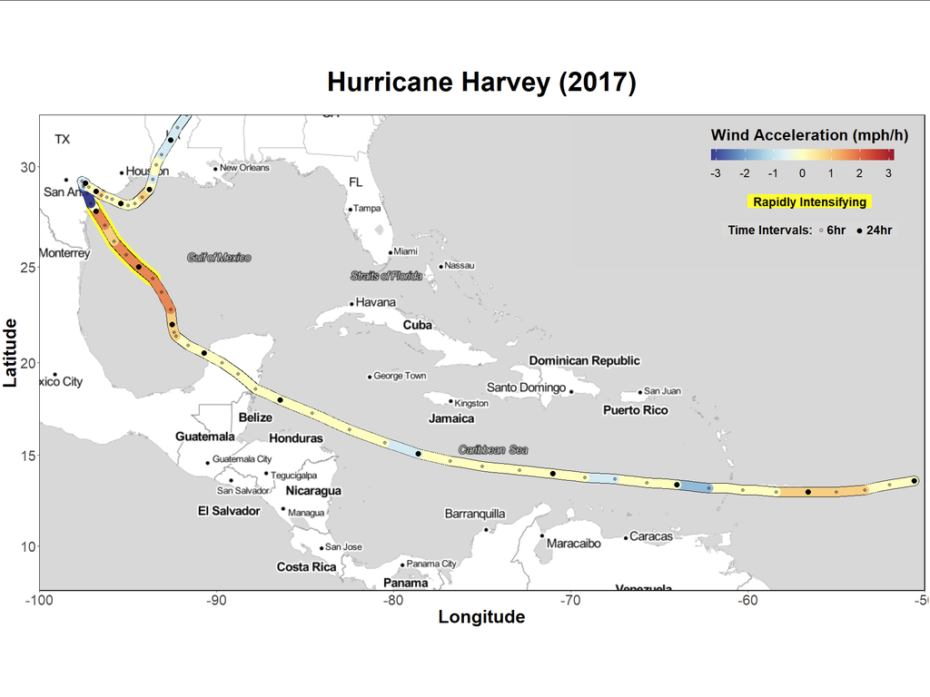

**Lessons Learned So Far**

**Reading pixel data from maps is hard!**

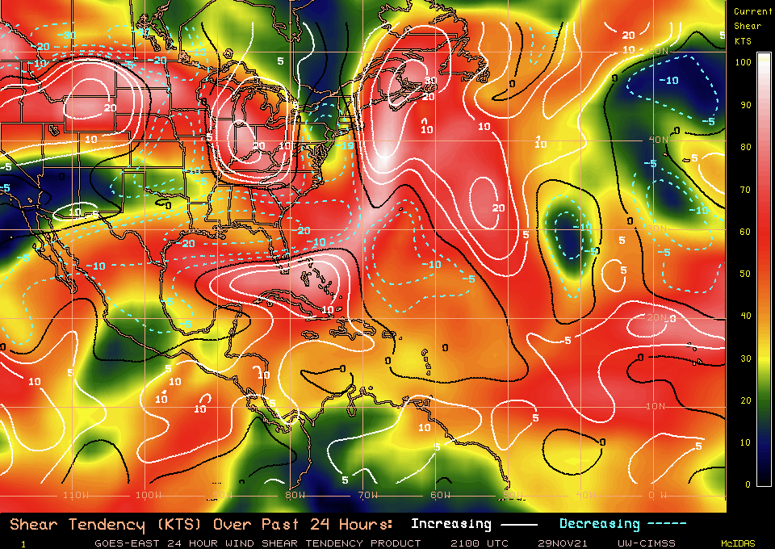

**Time series machine learning is hard!**

[figure not shown]

**Questions? Too Bad!**